# Lab 9.1

2026-02-05

> **For Big-Data Scientists, “Janitor Work” Is Key Hurdle to Insights.**  
> “Data scientists, according to interviews and expert estimates, spend from 50 percent to 80 percent of their time mired in the mundane labor of collecting and preparing data, before it can be explored for useful information.”  
> [New York Times](http://www.nytimes.com/2014/08/18/technology/for-big-data-scientists-hurdle-to-insights-is-janitor-work.html)

## Learning Goals

*At the end of this exercise, you will be able to:*  
1. Explain the difference between tidy and messy data.  
2. Evaluate a data set as tidy or messy.  
3. Use the `pivot_longer()` function of `tidyr` to transform data from wide to long format.  
4. Use `separate()` to split observations within a column.

## Overview

The quote above sums up much of the work in data science. Simply put, most of the data that you end up working with will be messy, disorganized, and not **tidy**. By the end of this week, you will have the tools necessary to wrangle messy data into tidy data that are ready for analysis. I know that we have spent a lot of time of data transformation, but this last step is essential to building plots and performing other analyses.

## Resources

- [tidyr `pivot_longer()`](https://tidyr.tidyverse.org/reference/pivot_longer.html)
- [pivoting](https://cran.r-project.org/web/packages/tidyr/vignettes/pivot.html)

## Load the tidyverse

```r
library("tidyverse")
library("janitor")
```

## Tidy data

Most “wild” data are organized incorrectly for work in R and, as you might expect, the tools used to transform data are a core part of the tidyverse. I will attempt to summarize the most important points below, but you should read [chapter 5 of the data science text](https://r4ds.hadley.nz/data-tidy.html) for a more thorough explanation.

`Tidy` data follows three conventions:  
(1) each variable has its own column  
(2) each observation has its own row  
(3) each value has its own cell

This is summarized in the image below. The package used to tidy data is called **tidyr** and is a core part of the tidyverse.

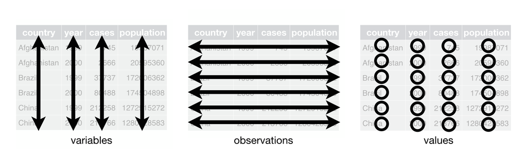

## `pivot_longer()`

Scientists use spreadsheets that are organized to make data entry efficient. This is often referred to as **wide format**. Unfortunately, the wide format creates a problem because column names may actually represent values of a variable. The command `pivot_longer()` shifts data from wide to long format.

Rules:  
+ `pivot_longer`(cols, names_to, values_to) + `cols` - Columns to pivot to longer format + `names_to` - Name of the new column; it will contain the column names of gathered columns as values + `values_to` - Name of the new column; it will contain the data stored in the values of gathered columns

## Example 1: column names are data

The following data show results from a drug trial with four treatments on six patients. The values represent resting heart rate.

```r
heartrate <- read_csv("data/heartrate.csv")
heartrate
```

```
## # A tibble: 6 × 5
##   patient      a     b     c     d
##   <chr>    <dbl> <dbl> <dbl> <dbl>
## 1 Margaret    72    74    80    68
## 2 Frank       84    84    88    76
## 3 Hawkeye     64    66    68    64
## 4 Trapper     60    58    64    58
## 5 Radar       74    72    78    70
## 6 Henry       88    87    88    72
```

[figure not shown]

```r
heartrate %>%
  ggplot(x = patient, y =) # Whole table cannot be ploted at once due to margent having four y values
```

Let’s assess whether or not these data are tidy.  
(1) each variable has its own column?

2. each observation has its own row?
3. each value has its own cell?

Let’s think about this another way- can we make a plot that shows the effect of each drug on Margaret’s heart rate? No, the data are not tidy.

To fix this problem, we need to reshape the table to long format while keeping track of column names and values. We do this using `pivot_longer()`. Notice that the dimensions of the data frame change.

```r
heartrate_long <- heartrate %>%
  pivot_longer(-patient, names_to = "drug", values_to = "heartrate")
heartrate_long
```

```
## # A tibble: 24 × 3
##    patient  drug  heartrate
##    <chr>    <chr>     <dbl>
##  1 Margaret a            72
##  2 Margaret b            74
##  3 Margaret c            80
##  4 Margaret d            68
##  5 Frank    a            84
##  6 Frank    b            84
##  7 Frank    c            88
##  8 Frank    d            76
##  9 Hawkeye  a            64
## 10 Hawkeye  b            66
## # ℹ 14 more rows
```

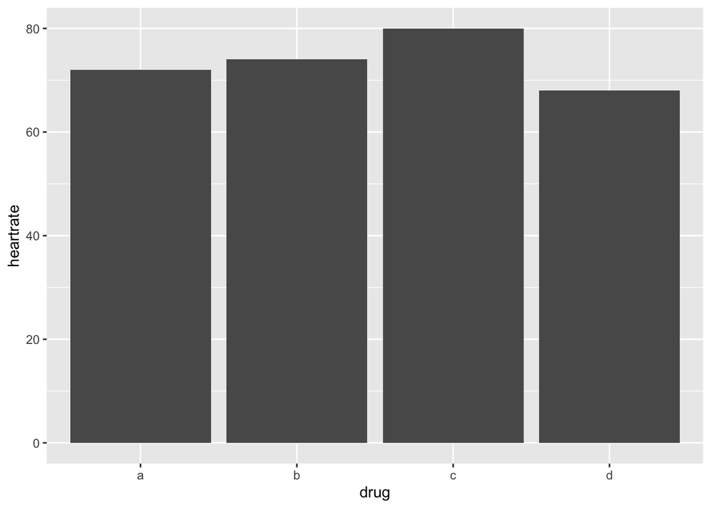

```r
heartrate_long %>%
  filter(patient =="Margaret") %>%
  ggplot(aes(x = drug, y = heartrate)) +
  geom_col()
```

## Practice 1. Import the file `relig_income.csv` and store it as a new object `relig_income`.

```r
relig_income <- read_csv("data/relig_income.csv")
relig_income
```

```
## # A tibble: 18 × 11
##    religion `<$10k` `$10-20k` `$20-30k` `$30-40k` `$40-50k` `$50-75k` `$75-100k`
##    <chr>      <dbl>     <dbl>     <dbl>     <dbl>     <dbl>     <dbl>      <dbl>
##  1 Agnostic      27        34        60        81        76       137        122
##  2 Atheist       12        27        37        52        35        70         73
##  3 Buddhist      27        21        30        34        33        58         62
##  4 Catholic     418       617       732       670       638      1116        949
##  5 Don’t k…      15        14        15        11        10        35         21
##  6 Evangel…     575       869      1064       982       881      1486        949
##  7 Hindu          1         9         7         9        11        34         47
##  8 Histori…     228       244       236       238       197       223        131
##  9 Jehovah…      20        27        24        24        21        30         15
## 10 Jewish        19        19        25        25        30        95         69
## 11 Mainlin…     289       495       619       655       651      1107        939
## 12 Mormon        29        40        48        51        56       112         85
## 13 Muslim         6         7         9        10         9        23         16
## 14 Orthodox      13        17        23        32        32        47         38
## 15 Other C…       9         7        11        13        13        14         18
## 16 Other F…      20        33        40        46        49        63         46
## 17 Other W…       5         2         3         4         2         7          3
## 18 Unaffil…     217       299       374       365       341       528        407
## # ℹ 3 more variables: `$100-150k` <dbl>, `>150k` <dbl>,
## #   `Don't know/refused` <dbl>
```

Note: `read_csv` includes special characters in variable names but also can turn dbls to characters. \ 2. Why are these data untidy?  
\ No religion has their own separate rows of each X.# value  
3. Use `pivot_longer()` to make the data tidy.

```r
relig_income_long <- relig_income %>%
  pivot_longer(-religion, names_to = "income", values_to = "total")
relig_income_long
```

```
## # A tibble: 180 × 3
##    religion income             total
##    <chr>    <chr>              <dbl>
##  1 Agnostic <$10k                 27
##  2 Agnostic $10-20k               34
##  3 Agnostic $20-30k               60
##  4 Agnostic $30-40k               81
##  5 Agnostic $40-50k               76
##  6 Agnostic $50-75k              137
##  7 Agnostic $75-100k             122
##  8 Agnostic $100-150k            109
##  9 Agnostic >150k                 84
## 10 Agnostic Don't know/refused    96
## # ℹ 170 more rows
```

## Example 2: some column names are data

Some (but not all) of the column names are data. We also have NA’s.

```r
billboard <- read_csv("data/billboard.csv")
billboard
```

```
## # A tibble: 317 × 79
##    artist     track date.entered   wk1   wk2   wk3   wk4   wk5   wk6   wk7   wk8
##    <chr>      <chr> <date>       <dbl> <dbl> <dbl> <dbl> <dbl> <dbl> <dbl> <dbl>
##  1 2 Pac      Baby… 2000-02-26      87    82    72    77    87    94    99    NA
##  2 2Ge+her    The … 2000-09-02      91    87    92    NA    NA    NA    NA    NA
##  3 3 Doors D… Kryp… 2000-04-08      81    70    68    67    66    57    54    53
##  4 3 Doors D… Loser 2000-10-21      76    76    72    69    67    65    55    59
##  5 504 Boyz   Wobb… 2000-04-15      57    34    25    17    17    31    36    49
##  6 98^0       Give… 2000-08-19      51    39    34    26    26    19     2     2
##  7 A*Teens    Danc… 2000-07-08      97    97    96    95   100    NA    NA    NA
##  8 Aaliyah    I Do… 2000-01-29      84    62    51    41    38    35    35    38
##  9 Aaliyah    Try … 2000-03-18      59    53    38    28    21    18    16    14
## 10 Adams, Yo… Open… 2000-08-26      76    76    74    69    68    67    61    58
## # ℹ 307 more rows
## # ℹ 68 more variables: wk9 <dbl>, wk10 <dbl>, wk11 <dbl>, wk12 <dbl>,
## #   wk13 <dbl>, wk14 <dbl>, wk15 <dbl>, wk16 <dbl>, wk17 <dbl>, wk18 <dbl>,
## #   wk19 <dbl>, wk20 <dbl>, wk21 <dbl>, wk22 <dbl>, wk23 <dbl>, wk24 <dbl>,
## #   wk25 <dbl>, wk26 <dbl>, wk27 <dbl>, wk28 <dbl>, wk29 <dbl>, wk30 <dbl>,
## #   wk31 <dbl>, wk32 <dbl>, wk33 <dbl>, wk34 <dbl>, wk35 <dbl>, wk36 <dbl>,
## #   wk37 <dbl>, wk38 <dbl>, wk39 <dbl>, wk40 <dbl>, wk41 <dbl>, wk42 <dbl>, …
```

Solution 1: specify a range of columns that you want to pivot.

```r
billboard_long1 <- billboard %>%
  pivot_longer(
    wk1:wk76,# Specify columns to pivot
    names_to = "week",
    values_to = "rank",
    values_drop_na = T # Remove all 'NA' values
    )
billboard_long1
```

```
## # A tibble: 5,307 × 5
##    artist  track                   date.entered week   rank
##    <chr>   <chr>                   <date>       <chr> <dbl>
##  1 2 Pac   Baby Don't Cry (Keep... 2000-02-26   wk1      87
##  2 2 Pac   Baby Don't Cry (Keep... 2000-02-26   wk2      82
##  3 2 Pac   Baby Don't Cry (Keep... 2000-02-26   wk3      72
##  4 2 Pac   Baby Don't Cry (Keep... 2000-02-26   wk4      77
##  5 2 Pac   Baby Don't Cry (Keep... 2000-02-26   wk5      87
##  6 2 Pac   Baby Don't Cry (Keep... 2000-02-26   wk6      94
##  7 2 Pac   Baby Don't Cry (Keep... 2000-02-26   wk7      99
##  8 2Ge+her The Hardest Part Of ... 2000-09-02   wk1      91
##  9 2Ge+her The Hardest Part Of ... 2000-09-02   wk2      87
## 10 2Ge+her The Hardest Part Of ... 2000-09-02   wk3      92
## # ℹ 5,297 more rows
```

Solution 2: OR, specify columns that you want to stay fixed.

```r
billboard_long2 <- billboard %>%
  pivot_longer(
    -c(artist, track, date.entered),# Specify columns to NOT to pivot
    names_to = "week",
    values_to = "rank",
    values_drop_na = T # Remove all 'NA' values
    )
billboard_long2
```

```
## # A tibble: 5,307 × 5
##    artist  track                   date.entered week   rank
##    <chr>   <chr>                   <date>       <chr> <dbl>
##  1 2 Pac   Baby Don't Cry (Keep... 2000-02-26   wk1      87
##  2 2 Pac   Baby Don't Cry (Keep... 2000-02-26   wk2      82
##  3 2 Pac   Baby Don't Cry (Keep... 2000-02-26   wk3      72
##  4 2 Pac   Baby Don't Cry (Keep... 2000-02-26   wk4      77
##  5 2 Pac   Baby Don't Cry (Keep... 2000-02-26   wk5      87
##  6 2 Pac   Baby Don't Cry (Keep... 2000-02-26   wk6      94
##  7 2 Pac   Baby Don't Cry (Keep... 2000-02-26   wk7      99
##  8 2Ge+her The Hardest Part Of ... 2000-09-02   wk1      91
##  9 2Ge+her The Hardest Part Of ... 2000-09-02   wk2      87
## 10 2Ge+her The Hardest Part Of ... 2000-09-02   wk3      92
## # ℹ 5,297 more rows
```

Solution 3: identify columns by a prefix, remove the prefix and all NA’s.

```r
billboard_long3 <- billboard %>%
  pivot_longer(
    cols = starts_with("wk"), # Specify columns to pivot by prefix "wk"
    names_to = "week",
    names_prefix = "wk", # Identify prefix to drop
    values_to = "rank",
    values_drop_na = T # Remove all 'NA' values
    )
billboard_long3
```

```
## # A tibble: 5,307 × 5
##    artist  track                   date.entered week   rank
##    <chr>   <chr>                   <date>       <chr> <dbl>
##  1 2 Pac   Baby Don't Cry (Keep... 2000-02-26   1        87
##  2 2 Pac   Baby Don't Cry (Keep... 2000-02-26   2        82
##  3 2 Pac   Baby Don't Cry (Keep... 2000-02-26   3        72
##  4 2 Pac   Baby Don't Cry (Keep... 2000-02-26   4        77
##  5 2 Pac   Baby Don't Cry (Keep... 2000-02-26   5        87
##  6 2 Pac   Baby Don't Cry (Keep... 2000-02-26   6        94
##  7 2 Pac   Baby Don't Cry (Keep... 2000-02-26   7        99
##  8 2Ge+her The Hardest Part Of ... 2000-09-02   1        91
##  9 2Ge+her The Hardest Part Of ... 2000-09-02   2        87
## 10 2Ge+her The Hardest Part Of ... 2000-09-02   3        92
## # ℹ 5,297 more rows
```

## Practice

1. Import `plant_data.csv` as a new object `plant_data`.

```r
plant_data <- read_csv("data/plant_data.csv")
plant_data
```

```
## # A tibble: 3 × 33
##   genotype water_sched_prog greenhouse  day1  day2  day3  day4  day5  day6  day7
##   <chr>    <chr>            <chr>      <dbl> <dbl> <dbl> <dbl> <dbl> <dbl> <dbl>
## 1 control  A                A761        21.7  19.9  20.7  19.4  20.2  19.2  20.6
## 2 mutant1  A                A761        24.3  24.9  25.2  25.3  27.4  25.5  25.4
## 3 mutant2  A                A761        20.7  21.3  21.3  22.5  19.8  21.4  21.9
## # ℹ 23 more variables: day8 <dbl>, day9 <dbl>, day10 <dbl>, day11 <dbl>,
## #   day12 <dbl>, day13 <dbl>, day14 <dbl>, day15 <dbl>, day16 <dbl>,
## #   day17 <dbl>, day18 <dbl>, day19 <dbl>, day20 <dbl>, day21 <dbl>,
## #   day22 <dbl>, day23 <dbl>, day24 <dbl>, day25 <dbl>, day26 <dbl>,
## #   day27 <dbl>, day28 <dbl>, day29 <dbl>, day30 <dbl>
```

2. Why are these data not tidy?  
   Each observation of genotype does not have its own row.
3. Use `pivot_longer()` to make the data tidy. Focus the data only on genotype, water_sched_prog, and greenhouse.

```r
plant_data_long <- plant_data %>%
  pivot_longer(
    cols = starts_with("day"),
    names_to = "Day",
    names_prefix = "day",
    values_to = "Height"
  )
plant_data_long
```

```
## # A tibble: 90 × 5
##    genotype water_sched_prog greenhouse Day   Height
##    <chr>    <chr>            <chr>      <chr>  <dbl>
##  1 control  A                A761       1       21.7
##  2 control  A                A761       2       19.9
##  3 control  A                A761       3       20.7
##  4 control  A                A761       4       19.4
##  5 control  A                A761       5       20.2
##  6 control  A                A761       6       19.2
##  7 control  A                A761       7       20.6
##  8 control  A                A761       8       19.9
##  9 control  A                A761       9       19.2
## 10 control  A                A761       10      20.4
## # ℹ 80 more rows
```

## Example 3: more than one variable in a column name

In this case, there are two observations in each column name.

```r
qpcr_untidy <- read_csv("data/qpcr_untidy.csv")
qpcr_untidy
```

```
## # A tibble: 5 × 10
##   gene  exp1_rep1 exp1_rep2 exp1_rep3 exp2_rep1 exp2_rep2 exp2_rep3 exp3_rep1
##   <chr>     <dbl>     <dbl>     <dbl>     <dbl>     <dbl>     <dbl>     <dbl>
## 1 A          21.7      19.8      20.7      18.3      20.4      17.6      20.6
## 2 B          24.3      24.8      25.2      26.0      29.9      26.4      25.4
## 3 C          20.7      21.5      21.3      25.5      18.7      22.3      21.9
## 4 D          26.9      28.0      27.7      33.1      24.3      28.9      28.5
## 5 E          25.0      22.7      23.8      21.1      23.4      20.2      23.7
## # ℹ 2 more variables: exp3_rep2 <dbl>, exp3_rep3 <dbl>
```

## That’s it! Let’s move on to part 2!

–>[Home](https://jmledford3115.github.io/datascibiol/)